# Optimal Treatment Analysis

## Outcome Variable

**Outcome Variable:** ever_wasted

## Predictor Variables

**Intervention Variable:** fage

**Adjustment Set:**

- arm
- W_mage
- meducyrs
- feducyrs
- W_mhtcm
- W_mwtkg
- W_mbmi
- W_fhtcm
- single
- brthmon
- delta_W_mage
- delta_meducyrs
- delta_feducyrs
- delta_W_mhtcm
- delta_W_mwtkg
- delta_W_mbmi
- delta_W_fhtcm
- delta_single
- delta_brthmon

## Stratifying Variables

The analysis was stratified on these variable(s):

- agecat
- studyid
- country

## Data Summary

| agecat | studyid | country | fage | ever_wasted | n_cell | n |
| --- | --- | --- | --- | --- | --- | --- |
| 0-24 months | ki0047075b-MAL-ED | BANGLADESH | >=38 | 0 | 46 | 151 |
| 0-24 months | ki0047075b-MAL-ED | BANGLADESH | >=38 | 1 | 23 | 151 |
| 0-24 months | ki0047075b-MAL-ED | BANGLADESH | <32 | 0 | 15 | 151 |
| 0-24 months | ki0047075b-MAL-ED | BANGLADESH | <32 | 1 | 15 | 151 |
| 0-24 months | ki0047075b-MAL-ED | BANGLADESH | [32-38) | 0 | 39 | 151 |
| 0-24 months | ki0047075b-MAL-ED | BANGLADESH | [32-38) | 1 | 13 | 151 |
| 0-24 months | ki0047075b-MAL-ED | BRAZIL | >=38 | 0 | 30 | 79 |
| 0-24 months | ki0047075b-MAL-ED | BRAZIL | >=38 | 1 | 0 | 79 |
| 0-24 months | ki0047075b-MAL-ED | BRAZIL | <32 | 0 | 16 | 79 |
| 0-24 months | ki0047075b-MAL-ED | BRAZIL | <32 | 1 | 2 | 79 |
| 0-24 months | ki0047075b-MAL-ED | BRAZIL | [32-38) | 0 | 28 | 79 |
| 0-24 months | ki0047075b-MAL-ED | BRAZIL | [32-38) | 1 | 3 | 79 |
| 0-24 months | ki0047075b-MAL-ED | INDIA | >=38 | 0 | 25 | 161 |
| 0-24 months | ki0047075b-MAL-ED | INDIA | >=38 | 1 | 11 | 161 |
| 0-24 months | ki0047075b-MAL-ED | INDIA | <32 | 0 | 20 | 161 |
| 0-24 months | ki0047075b-MAL-ED | INDIA | <32 | 1 | 33 | 161 |
| 0-24 months | ki0047075b-MAL-ED | INDIA | [32-38) | 0 | 36 | 161 |
| 0-24 months | ki0047075b-MAL-ED | INDIA | [32-38) | 1 | 36 | 161 |
| 0-24 months | ki0047075b-MAL-ED | NEPAL | >=38 | 0 | 13 | 79 |
| 0-24 months | ki0047075b-MAL-ED | NEPAL | >=38 | 1 | 4 | 79 |
| 0-24 months | ki0047075b-MAL-ED | NEPAL | <32 | 0 | 8 | 79 |
| 0-24 months | ki0047075b-MAL-ED | NEPAL | <32 | 1 | 7 | 79 |
| 0-24 months | ki0047075b-MAL-ED | NEPAL | [32-38) | 0 | 34 | 79 |
| 0-24 months | ki0047075b-MAL-ED | NEPAL | [32-38) | 1 | 13 | 79 |
| 0-24 months | ki0047075b-MAL-ED | PERU | >=38 | 0 | 26 | 85 |
| 0-24 months | ki0047075b-MAL-ED | PERU | >=38 | 1 | 1 | 85 |
| 0-24 months | ki0047075b-MAL-ED | PERU | <32 | 0 | 25 | 85 |
| 0-24 months | ki0047075b-MAL-ED | PERU | <32 | 1 | 4 | 85 |
| 0-24 months | ki0047075b-MAL-ED | PERU | [32-38) | 0 | 26 | 85 |
| 0-24 months | ki0047075b-MAL-ED | PERU | [32-38) | 1 | 3 | 85 |

[output cut: 204 more lines]

The following strata were considered:

- agecat: 0-24 months, studyid: ki0047075b-MAL-ED, country: BANGLADESH
- agecat: 0-24 months, studyid: ki0047075b-MAL-ED, country: BRAZIL
- agecat: 0-24 months, studyid: ki0047075b-MAL-ED, country: INDIA
- agecat: 0-24 months, studyid: ki0047075b-MAL-ED, country: NEPAL
- agecat: 0-24 months, studyid: ki0047075b-MAL-ED, country: PERU
- agecat: 0-24 months, studyid: ki0047075b-MAL-ED, country: SOUTH AFRICA
- agecat: 0-24 months, studyid: ki0047075b-MAL-ED, country: TANZANIA, UNITED REPUBLIC OF
- agecat: 0-24 months, studyid: ki1000304b-SAS-CompFeed, country: INDIA
- agecat: 0-24 months, studyid: ki1000304b-SAS-FoodSuppl, country: INDIA
- agecat: 0-24 months, studyid: ki1119695-PROBIT, country: BELARUS
- agecat: 0-24 months, studyid: ki1135781-COHORTS, country: GUATEMALA
- agecat: 0-24 months, studyid: ki1135781-COHORTS, country: PHILIPPINES
- agecat: 0-24 months, studyid: ki1148112-LCNI-5, country: MALAWI
- agecat: 0-6 months, studyid: ki0047075b-MAL-ED, country: BANGLADESH
- agecat: 0-6 months, studyid: ki0047075b-MAL-ED, country: BRAZIL
- agecat: 0-6 months, studyid: ki0047075b-MAL-ED, country: INDIA
- agecat: 0-6 months, studyid: ki0047075b-MAL-ED, country: NEPAL
- agecat: 0-6 months, studyid: ki0047075b-MAL-ED, country: PERU
- agecat: 0-6 months, studyid: ki0047075b-MAL-ED, country: SOUTH AFRICA
- agecat: 0-6 months, studyid: ki0047075b-MAL-ED, country: TANZANIA, UNITED REPUBLIC OF
- agecat: 0-6 months, studyid: ki1000304b-SAS-CompFeed, country: INDIA
- agecat: 0-6 months, studyid: ki1000304b-SAS-FoodSuppl, country: INDIA
- agecat: 0-6 months, studyid: ki1119695-PROBIT, country: BELARUS
- agecat: 0-6 months, studyid: ki1135781-COHORTS, country: GUATEMALA
- agecat: 0-6 months, studyid: ki1135781-COHORTS, country: PHILIPPINES
- agecat: 0-6 months, studyid: ki1148112-LCNI-5, country: MALAWI
- agecat: 6-24 months, studyid: ki0047075b-MAL-ED, country: BANGLADESH
- agecat: 6-24 months, studyid: ki0047075b-MAL-ED, country: BRAZIL
- agecat: 6-24 months, studyid: ki0047075b-MAL-ED, country: INDIA
- agecat: 6-24 months, studyid: ki0047075b-MAL-ED, country: NEPAL
- agecat: 6-24 months, studyid: ki0047075b-MAL-ED, country: PERU
- agecat: 6-24 months, studyid: ki0047075b-MAL-ED, country: SOUTH AFRICA
- agecat: 6-24 months, studyid: ki0047075b-MAL-ED, country: TANZANIA, UNITED REPUBLIC OF
- agecat: 6-24 months, studyid: ki1000304b-SAS-CompFeed, country: INDIA
- agecat: 6-24 months, studyid: ki1000304b-SAS-FoodSuppl, country: INDIA
- agecat: 6-24 months, studyid: ki1119695-PROBIT, country: BELARUS
- agecat: 6-24 months, studyid: ki1135781-COHORTS, country: GUATEMALA
- agecat: 6-24 months, studyid: ki1135781-COHORTS, country: PHILIPPINES
- agecat: 6-24 months, studyid: ki1148112-LCNI-5, country: MALAWI

### Dropped Strata

Some strata were dropped due to rare outcomes:

- agecat: 0-24 months, studyid: ki0047075b-MAL-ED, country: BRAZIL
- agecat: 0-24 months, studyid: ki0047075b-MAL-ED, country: NEPAL
- agecat: 0-24 months, studyid: ki0047075b-MAL-ED, country: PERU
- agecat: 0-24 months, studyid: ki0047075b-MAL-ED, country: SOUTH AFRICA
- agecat: 0-24 months, studyid: ki0047075b-MAL-ED, country: TANZANIA, UNITED REPUBLIC OF
- agecat: 0-24 months, studyid: ki1000304b-SAS-CompFeed, country: INDIA
- agecat: 0-24 months, studyid: ki1148112-LCNI-5, country: MALAWI
- agecat: 0-6 months, studyid: ki0047075b-MAL-ED, country: BRAZIL
- agecat: 0-6 months, studyid: ki0047075b-MAL-ED, country: NEPAL
- agecat: 0-6 months, studyid: ki0047075b-MAL-ED, country: PERU
- agecat: 0-6 months, studyid: ki0047075b-MAL-ED, country: SOUTH AFRICA
- agecat: 0-6 months, studyid: ki0047075b-MAL-ED, country: TANZANIA, UNITED REPUBLIC OF
- agecat: 0-6 months, studyid: ki1000304b-SAS-CompFeed, country: INDIA
- agecat: 0-6 months, studyid: ki1000304b-SAS-FoodSuppl, country: INDIA
- agecat: 0-6 months, studyid: ki1148112-LCNI-5, country: MALAWI
- agecat: 6-24 months, studyid: ki0047075b-MAL-ED, country: BRAZIL
- agecat: 6-24 months, studyid: ki0047075b-MAL-ED, country: NEPAL
- agecat: 6-24 months, studyid: ki0047075b-MAL-ED, country: PERU
- agecat: 6-24 months, studyid: ki0047075b-MAL-ED, country: SOUTH AFRICA
- agecat: 6-24 months, studyid: ki0047075b-MAL-ED, country: TANZANIA, UNITED REPUBLIC OF
- agecat: 6-24 months, studyid: ki1000304b-SAS-CompFeed, country: INDIA
- agecat: 6-24 months, studyid: ki1000304b-SAS-FoodSuppl, country: INDIA
- agecat: 6-24 months, studyid: ki1119695-PROBIT, country: BELARUS
- agecat: 6-24 months, studyid: ki1148112-LCNI-5, country: MALAWI

## Methods Detail

We’re interested in the causal parameters $E[Y_a]$ for all values of $a \in \mathcal{A}$. These parameters represent the mean outcome if, possibly contrary to fact, we intervened to set all units to have $A=a$. Under the randomization and positivity assumptions, these are identified by the statistical parameters $\psi_a=E_W[E_{Y|A,W}(Y|A=a,W)]$. In addition, we’re interested in the mean of $Y$, $E[Y]$ under no intervention (the observed mean). We will estimate these parameters by using SuperLearner to fit the relevant likelihood factors – $E_{Y|A,W}(Y|A=a,W)$ and $p(A=a|W)$, and then updating our likelihood fit using a joint TMLE.

For unadjusted analyses ($W=\{\}$), initial likelihoods were estimated using Lrnr_glm to estimate the simple $E(Y|A)$ and Lrnr_mean to estimate $p(A)$. For adjusted analyses, a small library containing Lrnr_glmnet, Lrnr_xgboost, and Lrnr_mean was used.

Having estimated these parameters, we will then use the delta method to estimate relative risks and attributable risks relative to a prespecified baseline level of $A$.

# Results Detail

## Results Plots

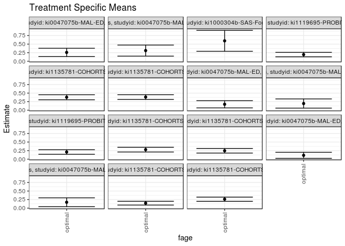

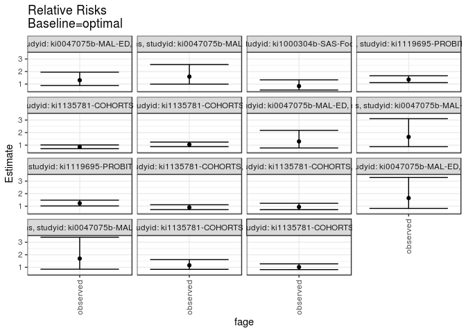

## Results Table

### Parameter: TSM

| agecat | studyid | country | intervention_level | baseline_level | estimate | ci_lower | ci_upper |
| --- | --- | --- | --- | --- | --- | --- | --- |
| 0-24 months | ki0047075b-MAL-ED | BANGLADESH | optimal | NA | 0.2579774 | 0.1366431 | 0.3793116 |
| 0-24 months | ki0047075b-MAL-ED | INDIA | optimal | NA | 0.3114763 | 0.1498149 | 0.4731376 |
| 0-24 months | ki1000304b-SAS-FoodSuppl | INDIA | optimal | NA | 0.5960592 | 0.2902375 | 0.9018808 |
| 0-24 months | ki1119695-PROBIT | BELARUS | optimal | NA | 0.1944536 | 0.1292442 | 0.2596630 |
| 0-24 months | ki1135781-COHORTS | GUATEMALA | optimal | NA | 0.3783413 | 0.3047694 | 0.4519132 |
| 0-24 months | ki1135781-COHORTS | PHILIPPINES | optimal | NA | 0.3839519 | 0.3147107 | 0.4531930 |
| 0-6 months | ki0047075b-MAL-ED | BANGLADESH | optimal | NA | 0.1735046 | 0.0681688 | 0.2788405 |
| 0-6 months | ki0047075b-MAL-ED | INDIA | optimal | NA | 0.1952427 | 0.0610309 | 0.3294545 |
| 0-6 months | ki1119695-PROBIT | BELARUS | optimal | NA | 0.2096949 | 0.1426951 | 0.2766946 |
| 0-6 months | ki1135781-COHORTS | GUATEMALA | optimal | NA | 0.2784282 | 0.2099304 | 0.3469260 |
| 0-6 months | ki1135781-COHORTS | PHILIPPINES | optimal | NA | 0.2458391 | 0.1787185 | 0.3129596 |
| 6-24 months | ki0047075b-MAL-ED | BANGLADESH | optimal | NA | 0.1123275 | 0.0238716 | 0.2007834 |
| 6-24 months | ki0047075b-MAL-ED | INDIA | optimal | NA | 0.1719575 | 0.0430689 | 0.3008462 |
| 6-24 months | ki1135781-COHORTS | GUATEMALA | optimal | NA | 0.1457407 | 0.0901636 | 0.2013177 |
| 6-24 months | ki1135781-COHORTS | PHILIPPINES | optimal | NA | 0.2611134 | 0.2002663 | 0.3219605 |

### Parameter: E(Y)

| agecat | studyid | country | intervention_level | baseline_level | estimate | ci_lower | ci_upper |
| --- | --- | --- | --- | --- | --- | --- | --- |
| 0-24 months | ki0047075b-MAL-ED | BANGLADESH | observed | NA | 0.3377483 | 0.2620632 | 0.4134335 |
| 0-24 months | ki0047075b-MAL-ED | INDIA | observed | NA | 0.4968944 | 0.4194215 | 0.5743673 |
| 0-24 months | ki1000304b-SAS-FoodSuppl | INDIA | observed | NA | 0.5000000 | 0.4043636 | 0.5956364 |
| 0-24 months | ki1119695-PROBIT | BELARUS | observed | NA | 0.2645591 | 0.1704386 | 0.3586795 |
| 0-24 months | ki1135781-COHORTS | GUATEMALA | observed | NA | 0.3231511 | 0.2863678 | 0.3599345 |
| 0-24 months | ki1135781-COHORTS | PHILIPPINES | observed | NA | 0.4018374 | 0.3841095 | 0.4195652 |
| 0-6 months | ki0047075b-MAL-ED | BANGLADESH | observed | NA | 0.2251656 | 0.1583223 | 0.2920089 |
| 0-6 months | ki0047075b-MAL-ED | INDIA | observed | NA | 0.3229814 | 0.2505249 | 0.3954378 |
| 0-6 months | ki1119695-PROBIT | BELARUS | observed | NA | 0.2588326 | 0.1637240 | 0.3539411 |
| 0-6 months | ki1135781-COHORTS | GUATEMALA | observed | NA | 0.2515337 | 0.2130371 | 0.2900303 |
| 0-6 months | ki1135781-COHORTS | PHILIPPINES | observed | NA | 0.2321307 | 0.2168619 | 0.2473995 |
| 6-24 months | ki0047075b-MAL-ED | BANGLADESH | observed | NA | 0.1854305 | 0.1232352 | 0.2476257 |
| 6-24 months | ki0047075b-MAL-ED | INDIA | observed | NA | 0.2919255 | 0.2214783 | 0.3623726 |
| 6-24 months | ki1135781-COHORTS | GUATEMALA | observed | NA | 0.1693122 | 0.1384161 | 0.2002082 |
| 6-24 months | ki1135781-COHORTS | PHILIPPINES | observed | NA | 0.2661765 | 0.2495644 | 0.2827886 |

### Parameter: RR

| agecat | studyid | country | intervention_level | baseline_level | estimate | ci_lower | ci_upper |
| --- | --- | --- | --- | --- | --- | --- | --- |
| 0-24 months | ki0047075b-MAL-ED | BANGLADESH | observed | optimal | 1.3092169 | 0.8799626 | 1.947866 |
| 0-24 months | ki0047075b-MAL-ED | INDIA | observed | optimal | 1.5952882 | 0.9941648 | 2.559882 |
| 0-24 months | ki1000304b-SAS-FoodSuppl | INDIA | observed | optimal | 0.8388429 | 0.5259883 | 1.337781 |
| 0-24 months | ki1119695-PROBIT | BELARUS | observed | optimal | 1.3605254 | 1.1136220 | 1.662170 |
| 0-24 months | ki1135781-COHORTS | GUATEMALA | observed | optimal | 0.8541260 | 0.7181339 | 1.015871 |
| 0-24 months | ki1135781-COHORTS | PHILIPPINES | observed | optimal | 1.0465827 | 0.8796145 | 1.245245 |
| 0-6 months | ki0047075b-MAL-ED | BANGLADESH | observed | optimal | 1.2977495 | 0.7740791 | 2.175687 |
| 0-6 months | ki0047075b-MAL-ED | INDIA | observed | optimal | 1.6542557 | 0.8790020 | 3.113260 |
| 0-6 months | ki1119695-PROBIT | BELARUS | observed | optimal | 1.2343296 | 1.0251999 | 1.486119 |
| 0-6 months | ki1135781-COHORTS | GUATEMALA | observed | optimal | 0.9034062 | 0.7289687 | 1.119585 |
| 0-6 months | ki1135781-COHORTS | PHILIPPINES | observed | optimal | 0.9442385 | 0.7230180 | 1.233145 |
| 6-24 months | ki0047075b-MAL-ED | BANGLADESH | observed | optimal | 1.6508023 | 0.8257568 | 3.300183 |
| 6-24 months | ki0047075b-MAL-ED | INDIA | observed | optimal | 1.6976601 | 0.8489934 | 3.394667 |
| 6-24 months | ki1135781-COHORTS | GUATEMALA | observed | optimal | 1.1617358 | 0.8364988 | 1.613427 |
| 6-24 months | ki1135781-COHORTS | PHILIPPINES | observed | optimal | 1.0193903 | 0.8149716 | 1.275083 |

### Parameter: PAR

| agecat | studyid | country | intervention_level | baseline_level | estimate | ci_lower | ci_upper |
| --- | --- | --- | --- | --- | --- | --- | --- |
| 0-24 months | ki0047075b-MAL-ED | BANGLADESH | optimal | NA | 0.0797710 | -0.0229638 | 0.1825058 |
| 0-24 months | ki0047075b-MAL-ED | INDIA | optimal | NA | 0.1854182 | 0.0394892 | 0.3313471 |
| 0-24 months | ki1000304b-SAS-FoodSuppl | INDIA | optimal | NA | -0.0960592 | -0.3757755 | 0.1836571 |
| 0-24 months | ki1119695-PROBIT | BELARUS | optimal | NA | 0.0701055 | 0.0164641 | 0.1237469 |
| 0-24 months | ki1135781-COHORTS | GUATEMALA | optimal | NA | -0.0551902 | -0.1202715 | 0.0098911 |
| 0-24 months | ki1135781-COHORTS | PHILIPPINES | optimal | NA | 0.0178855 | -0.0488317 | 0.0846028 |
| 0-6 months | ki0047075b-MAL-ED | BANGLADESH | optimal | NA | 0.0516609 | -0.0386278 | 0.1419496 |
| 0-6 months | ki0047075b-MAL-ED | INDIA | optimal | NA | 0.1277387 | 0.0032220 | 0.2522553 |
| 0-6 months | ki1119695-PROBIT | BELARUS | optimal | NA | 0.0491377 | -0.0012193 | 0.0994947 |
| 0-6 months | ki1135781-COHORTS | GUATEMALA | optimal | NA | -0.0268944 | -0.0862096 | 0.0324207 |
| 0-6 months | ki1135781-COHORTS | PHILIPPINES | optimal | NA | -0.0137084 | -0.0793132 | 0.0518965 |
| 6-24 months | ki0047075b-MAL-ED | BANGLADESH | optimal | NA | 0.0731030 | -0.0070700 | 0.1532760 |
| 6-24 months | ki0047075b-MAL-ED | INDIA | optimal | NA | 0.1199679 | -0.0006742 | 0.2406101 |
| 6-24 months | ki1135781-COHORTS | GUATEMALA | optimal | NA | 0.0235715 | -0.0243372 | 0.0714802 |
| 6-24 months | ki1135781-COHORTS | PHILIPPINES | optimal | NA | 0.0050631 | -0.0533731 | 0.0634992 |

### Parameter: PAF

| agecat | studyid | country | intervention_level | baseline_level | estimate | ci_lower | ci_upper |
| --- | --- | --- | --- | --- | --- | --- | --- |
| 0-24 months | ki0047075b-MAL-ED | BANGLADESH | optimal | NA | 0.2361846 | -0.1364119 | 0.4866176 |
| 0-24 months | ki0047075b-MAL-ED | INDIA | optimal | NA | 0.3731540 | -0.0058694 | 0.6093570 |
| 0-24 months | ki1000304b-SAS-FoodSuppl | INDIA | optimal | NA | -0.1921183 | -0.9011830 | 0.2524938 |
| 0-24 months | ki1119695-PROBIT | BELARUS | optimal | NA | 0.2649899 | 0.1020292 | 0.3983770 |
| 0-24 months | ki1135781-COHORTS | GUATEMALA | optimal | NA | -0.1707874 | -0.3924979 | 0.0156228 |
| 0-24 months | ki1135781-COHORTS | PHILIPPINES | optimal | NA | 0.0445093 | -0.1368617 | 0.1969450 |
| 0-6 months | ki0047075b-MAL-ED | BANGLADESH | optimal | NA | 0.2294352 | -0.2918577 | 0.5403750 |
| 0-6 months | ki0047075b-MAL-ED | INDIA | optimal | NA | 0.3954985 | -0.1376539 | 0.6787933 |
| 0-6 months | ki1119695-PROBIT | BELARUS | optimal | NA | 0.1898436 | 0.0245805 | 0.3271065 |
| 0-6 months | ki1135781-COHORTS | GUATEMALA | optimal | NA | -0.1069218 | -0.3718010 | 0.1068122 |
| 0-6 months | ki1135781-COHORTS | PHILIPPINES | optimal | NA | -0.0590545 | -0.3830915 | 0.1890656 |
| 6-24 months | ki0047075b-MAL-ED | BANGLADESH | optimal | NA | 0.3942339 | -0.2110103 | 0.6969865 |
| 6-24 months | ki0047075b-MAL-ED | INDIA | optimal | NA | 0.4109539 | -0.1778655 | 0.7054203 |
| 6-24 months | ki1135781-COHORTS | GUATEMALA | optimal | NA | 0.1392191 | -0.1954590 | 0.3802014 |
| 6-24 months | ki1135781-COHORTS | PHILIPPINES | optimal | NA | 0.0190214 | -0.2270366 | 0.2157374 |